# CaseStudy1

Tue Vu

2024-06-17

## Link to Youtube presentation

https://www.youtube.com/watch?v=I3wtLNDcjkU

## Step 1: Preparation

Remove current environment, set working directory and load necessary libraries

```r
rm(list=ls())
setwd("/Users/a46791130/Documents/SMU/SMU_MSDS/MSDS_6306_Doing-Data-Science-Master/Unit 8 and 9 Case Study 1")
library(tidyverse)
library(Amelia)
library(caret)
```

```r
library(ggplot2)
library(Amelia)
library(psych)
library(GGally)
library(e1071)
library(class)
library(glmnet)
library(psych)
library(rpart)
library(plotmo)
library(rattle)
```

First load the input data file and check the missing value

```r
data <- read.csv("CaseStudy1-data.csv")
sum(is.na(data))
```

```
## [1] 0
```

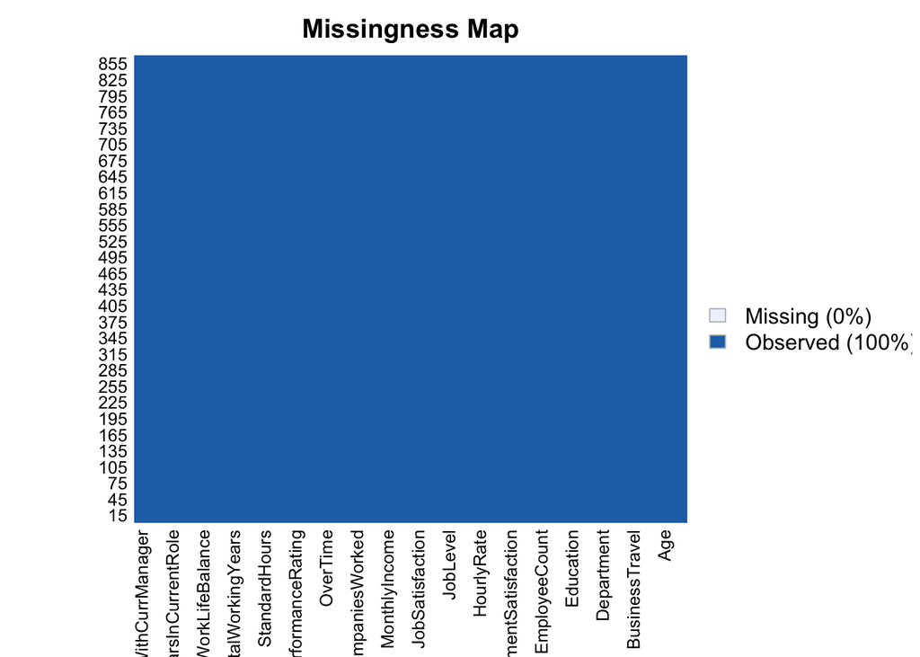

```r
# An alternative way to visualize the missing data
missmap(data)
```

Quick way to see structure of data:

```r
dim(data)
```

```
## [1] 870  36
```

```r
str(data)
```

```
## 'data.frame':    870 obs. of  36 variables:
##  $ ID                      : int  1 2 3 4 5 6 7 8 9 10 ...
##  $ Age                     : int  32 40 35 32 24 27 41 37 34 34 ...
##  $ Attrition               : chr  "No" "No" "No" "No" ...
##  $ BusinessTravel          : chr  "Travel_Rarely" "Travel_Rarely" "Travel_Frequently" "Travel_Rarely" ...
##  $ DailyRate               : int  117 1308 200 801 567 294 1283 309 1333 653 ...
##  $ Department              : chr  "Sales" "Research & Development" "Research & Development" "Sales" ...
##  $ DistanceFromHome        : int  13 14 18 1 2 10 5 10 10 10 ...
##  $ Education               : int  4 3 2 4 1 2 5 4 4 4 ...
##  $ EducationField          : chr  "Life Sciences" "Medical" "Life Sciences" "Marketing" ...
##  $ EmployeeCount           : int  1 1 1 1 1 1 1 1 1 1 ...
##  $ EmployeeNumber          : int  859 1128 1412 2016 1646 733 1448 1105 1055 1597 ...
##  $ EnvironmentSatisfaction : int  2 3 3 3 1 4 2 4 3 4 ...
##  $ Gender                  : chr  "Male" "Male" "Male" "Female" ...
##  $ HourlyRate              : int  73 44 60 48 32 32 90 88 87 92 ...
```

[output cut: 22 more lines]

There are 870 employee was in the survey and 36 survey questions were asked represented by predictors

Another way to describe the data

```r
describe(data)
```

```
##                          vars   n     mean      sd  median  trimmed     mad
## ID                          1 870   435.50  251.29   435.5   435.50  322.47
## Age                         2 870    36.83    8.93    35.0    36.39    8.90
## Attrition*                  3 870     1.16    0.37     1.0     1.08    0.00
## BusinessTravel*             4 870     2.60    0.68     3.0     2.75    0.00
## DailyRate                   5 870   815.23  401.12   817.5   817.85  514.46
## Department*                 6 870     2.27    0.53     2.0     2.27    0.00
## DistanceFromHome            7 870     9.34    8.14     7.0     8.28    7.41
## Education                   8 870     2.90    1.02     3.0     2.96    1.48
## EducationField*             9 870     3.24    1.32     3.0     3.09    1.48
## EmployeeCount              10 870     1.00    0.00     1.0     1.00    0.00
## EmployeeNumber             11 870  1029.83  604.79  1039.0  1031.45  807.28
## EnvironmentSatisfaction    12 870     2.70    1.10     3.0     2.75    1.48
## Gender*                    13 870     1.59    0.49     2.0     1.62    0.00
## HourlyRate                 14 870    65.61   20.13    66.0    65.63   25.20
## JobInvolvement             15 870     2.72    0.70     3.0     2.73    0.00
## JobLevel                   16 870     2.04    1.09     2.0     1.87    1.48
## JobRole*                   17 870     5.53    2.46     6.0     5.70    2.97
## JobSatisfaction            18 870     2.71    1.11     3.0     2.76    1.48
## MaritalStatus*             19 870     2.09    0.72     2.0     2.11    1.48
## MonthlyIncome              20 870  6390.26 4597.70  4945.5  5582.97 3304.72
## MonthlyRate                21 870 14325.62 7108.38 14074.5 14285.47 9273.66
## NumCompaniesWorked         22 870     2.73    2.52     2.0     2.40    1.48
## Over18*                    23 870     1.00    0.00     1.0     1.00    0.00
## OverTime*                  24 870     1.29    0.45     1.0     1.24    0.00
## PercentSalaryHike          25 870    15.20    3.68    14.0    14.78    2.97
## PerformanceRating          26 870     3.15    0.36     3.0     3.06    0.00
## RelationshipSatisfaction   27 870     2.71    1.10     3.0     2.76    1.48
## StandardHours              28 870    80.00    0.00    80.0    80.00    0.00
## StockOptionLevel           29 870     0.78    0.86     1.0     0.65    1.48
## TotalWorkingYears          30 870    11.05    7.51    10.0    10.19    5.93
## TrainingTimesLastYear      31 870     2.83    1.27     3.0     2.76    1.48
## WorkLifeBalance            32 870     2.78    0.71     3.0     2.80    0.00
## YearsAtCompany             33 870     6.96    6.02     5.0     6.00    4.45
## YearsInCurrentRole         34 870     4.20    3.64     3.0     3.83    4.45
## YearsSinceLastPromotion    35 870     2.17    3.19     1.0     1.47    1.48
## YearsWithCurrManager       36 870     4.14    3.57     3.0     3.81    4.45
##                           min   max range  skew kurtosis     se
## ID                          1   870   869  0.00    -1.20   8.52
## Age                        18    60    42  0.42    -0.31   0.30
```

[output cut: 19 more lines]

```
## NumCompaniesWorked          0     9     9  1.00    -0.07   0.09
## Over18*                     1     1     0   NaN      NaN   0.00
## OverTime*                   1     2     1  0.93    -1.14   0.02
## PercentSalaryHike          11    25    14  0.83    -0.28   0.12
## PerformanceRating           3     4     1  1.94     1.76   0.01
## RelationshipSatisfaction    1     4     3 -0.30    -1.24   0.04
## StandardHours              80    80     0   NaN      NaN   0.00
## StockOptionLevel            0     3     3  1.03     0.50   0.03
## TotalWorkingYears           0    40    40  1.13     1.09   0.25
## TrainingTimesLastYear       0     6     6  0.52     0.48   0.04
## WorkLifeBalance             1     4     3 -0.57     0.46   0.02
## YearsAtCompany              0    40    40  1.62     3.36   0.20
## YearsInCurrentRole          0    18    18  0.87     0.31   0.12
## YearsSinceLastPromotion     0    15    15  1.99     3.71   0.11
## YearsWithCurrManager        0    17    17  0.73    -0.15   0.12
```

Since there is no missing data, we are safe to proceed with Exploratory Data Analyses

First remove some unwanted variables - ID: this is an order number with increasing value and has no meaning in modeling - EmployeeCount: only contains 1 value - Over18: all working adult are over 18 - StandardHours: 80 are the same for everyone

```r
print(unique(data$EmployeeCount))
```

```
## [1] 1
```

```r
print(unique(data$Over18))
```

```
## [1] "Y"
```

```r
print(unique(data$StandardHours))
```

```
## [1] 80
```

```r
col2remove <- c(1,10,23,28)
data1 <- data[,-col2remove]
```

## Step 2: Exploratory Data Analyses

Let do some EDA by answering several questions:

1. How many percentage of Male/Female turn over rate?

```r
GY <- data %>% filter(Attrition=="Yes") %>% group_by(Gender) %>% summarise(nG=length(Gender))
GT <- data %>% group_by(Gender) %>% summarise(nT=length(Gender))
dG <- cbind(GY,GT)
dG$Percent <- dG$nG/dG$nT*100
dG
```

```
##   Gender nG Gender  nT  Percent
## 1 Female 53 Female 354 14.97175
## 2   Male 87   Male 516 16.86047
```

It seems that the turn over rate does not depend on Gender because among all male and female, the turn over rate for them are about 15%

2. Find out what JobRole has highest turn over rate?

```r
JRY <- data %>% filter(Attrition=="Yes") %>% group_by(JobRole) %>% summarise(nY=length(JobRole))
JRT <- data %>% group_by(JobRole) %>% summarise(nT=length(JobRole))

dJR <- cbind(JRY,JRT)
dJR$Percent <- (dJR$nY/dJR$nT)*100
dJR
```

```
##                     JobRole nY                   JobRole  nT   Percent
## 1 Healthcare Representative  8 Healthcare Representative  76 10.526316
## 2           Human Resources  6           Human Resources  27 22.222222
## 3     Laboratory Technician 30     Laboratory Technician 153 19.607843
## 4                   Manager  4                   Manager  51  7.843137
## 5    Manufacturing Director  2    Manufacturing Director  87  2.298851
## 6         Research Director  1         Research Director  51  1.960784
## 7        Research Scientist 32        Research Scientist 172 18.604651
## 8           Sales Executive 33           Sales Executive 200 16.500000
## 9      Sales Representative 24      Sales Representative  53 45.283019
```

We can see among all Job, people who works as Sales Representative has high chances of having Attrition (45%), second by Human Resources (22%), on the other hand Research Director accounted for only 2% (having lowest turn over rate) and quite similar to Manufacturing Director (2.2%).

3. What are average job satisfaction by job role?

```r
data %>% group_by(JobRole) %>% summarise(avg = mean(JobSatisfaction)) %>% arrange(desc(avg))
```

```
## # A tibble: 9 × 2
##   JobRole                     avg
##   <chr>                     <dbl>
## 1 Healthcare Representative  2.83
## 2 Research Scientist         2.80
## 3 Sales Executive            2.72
## 4 Manufacturing Director     2.72
## 5 Sales Representative       2.70
## 6 Laboratory Technician      2.69
## 7 Human Resources            2.56
## 8 Manager                    2.51
## 9 Research Director          2.49
```

From the analyses, All JobRole having average JobSatisfaction rate ranges from 2.5 to 2.8, and the highest average JobSatifaction goes to Healthcare Representative and lowest is for Research Director

We apply quick anova approach to see if there is any significant difference between the Job Satisfaction for each Job Role or not? State the Null Hypothesis: Ho: All Job Role have equal Job Satisfaction level. The Alternative Ha is: there exists at least 1 pair of Job Role do not have same Satisfaction level.

```r
fit <- aov(JobSatisfaction~JobRole,data=data)
summary(fit)
```

```
##              Df Sum Sq Mean Sq F value Pr(>F)
## JobRole       8    7.8  0.9811   0.788  0.613
## Residuals   861 1071.6  1.2446
```

We can see that F-value = 0.788 with p-value = 0.6 > the alpha (0.05) Thus we have decision that is failed to reject the Null Hypothesis. We come to conclusion that there is evidence to suggest all Job Role have similar Satisfaction rate.

4. What MaritalStatus overwhelme the decision to turn over?

```r
MSY <- data %>% filter(Attrition=="Yes") %>% group_by(MaritalStatus) %>% summarise(nY=length(MaritalStatus))
MST <- data %>% group_by(MaritalStatus) %>% summarise(nT=length(MaritalStatus))

dMS <- cbind(MSY,MST)
dMS$Percent <- (dMS$nY/dMS$nT)*100
dMS
```

```
##   MaritalStatus nY MaritalStatus  nT   Percent
## 1      Divorced 12      Divorced 191  6.282723
## 2       Married 58       Married 410 14.146341
## 3        Single 70        Single 269 26.022305
```

From the analyses, it seems that the Single has highest turn over rate (26%) and interestingly, the one who Divorced, has very low turn over rate (6%).

### (5) Monthly Salary according to JobRole, is there any different in Salary?

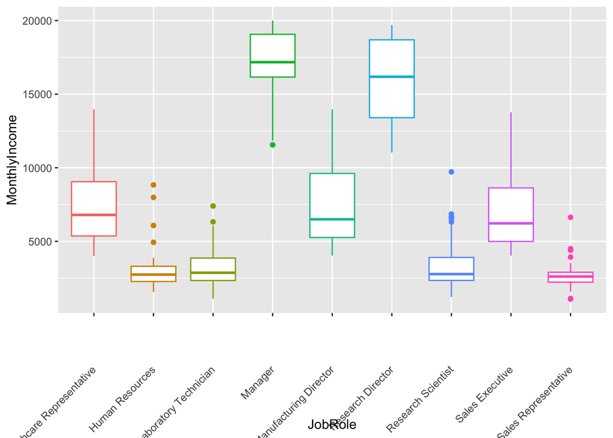

```r
ggplot(data,aes(x=JobRole,y=MonthlyIncome))+
        geom_boxplot(aes(color=JobRole))+
        theme(legend.position="none",axis.text.x = element_text(angle = 45, vjust = 0.5, hjust = 1))
```

To check the Hypothesis of equal Monthly Income, we use Anova test with Null Hypothesis that there exists equal mean MonthlyIncome across all Job Role

```r
fit_MI <- aov(MonthlyIncome~JobRole,data=data)
summary(fit_MI)
```

```
##              Df    Sum Sq   Mean Sq F value Pr(>F)
## JobRole       8 1.489e+10 1.861e+09   460.3 <2e-16 ***
## Residuals   861 3.481e+09 4.043e+06
## ---
## Signif. codes:  0 '***' 0.001 '**' 0.01 '*' 0.05 '.' 0.1 ' ' 1
```

The p-value is very small compare to alpha, suggesting to reject the Null Hypothesis and conclude that there is overwhelem evidences to show there exists at least 1 pair of Job Role with significant different mean value

### (6)

Since MonthlyIncome, DailyRate, HourlyRate and MonthlyRate are in $ values, we would like to see if there are any collinearity associated or not

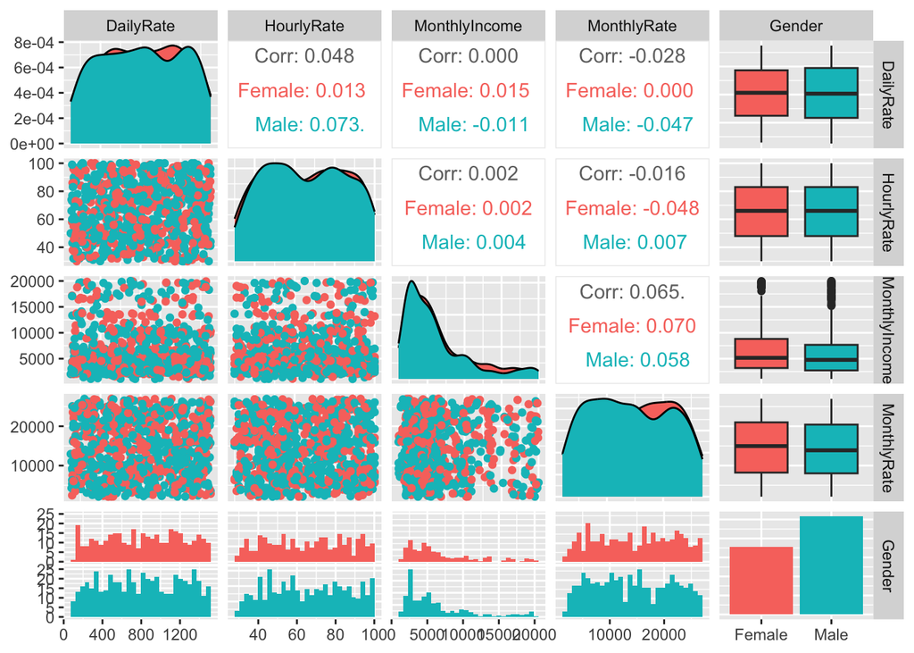

```r
c_rate <- c(5,14,20,21,13)
ggpairs(data[,c_rate],aes(color=Gender))
```

We can see there is literally no correlation between all income level, therefore, we do not remove any of these income level out of the calculation

Again we check for collinearity between some variables related to Year working (YearsAtCompany, YearsInCurrentRole,YearsSinceLastPromotion and YearsWithCurrManager)

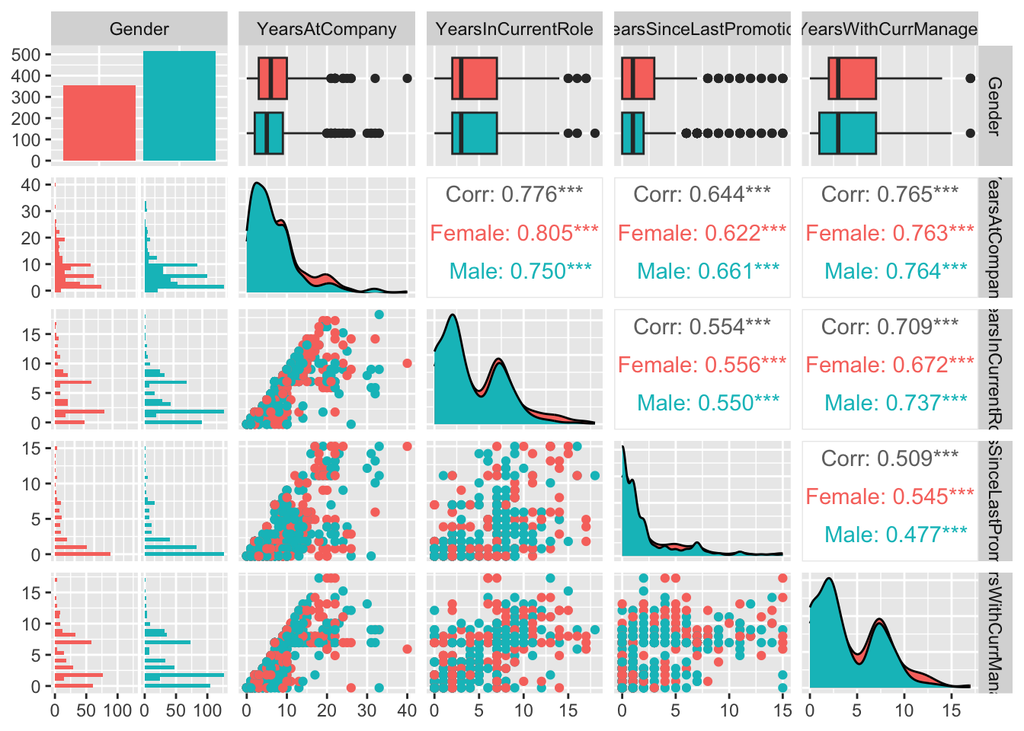

```r
ggpairs(data[,c(13,33:36)],aes(color=Gender))
```

The correlation value and scatteplot suggest correlation between YearsAtCompany with other 3 variables

## Step 3: Training the model and calculate Confusion Matrix

Split data into training and testing, we reserved 70% of data for training and 30% for testing

```r
set.seed(1234)
ind <- createDataPartition(y=data1$Attrition,p=0.7,list=FALSE)
training     <- data1[ind,]
testing      <- data1[-ind,]
```

In many ML method, Random Forest is one of the most versatile algorithm that can be applied for any type of input variable as well as output data no matter in continuous or categorical format. Random Forest is also an ML ensemble Bagging technique that helps to avoid OverFitting. Next we apply Random Forest for all predictors and quickly compute the confusion matrix for testing set:

```r
model_rf <- train(Attrition~.,data=training,method="rf")
print(model_rf)
```

```
## Random Forest
##
## 609 samples
##  31 predictor
##   2 classes: 'No', 'Yes'
##
## No pre-processing
## Resampling: Bootstrapped (25 reps)
## Summary of sample sizes: 609, 609, 609, 609, 609, 609, ...
## Resampling results across tuning parameters:
##
##   mtry  Accuracy   Kappa
##    2    0.8466409  0.04563302
##   23    0.8577980  0.25829339
##   45    0.8553258  0.27225457
##
## Accuracy was used to select the optimal model using the largest value.
## The final value used for the model was mtry = 23.
```

```r
predict_rf <- predict(model_rf,newdata=testing)
confusionMatrix(factor(testing$Attrition),predict_rf,positive="Yes")
```

```
## Confusion Matrix and Statistics
##
##           Reference
## Prediction  No Yes
##        No  216   3
##        Yes  33   9
##
##                Accuracy : 0.8621
##                  95% CI : (0.8142, 0.9015)
##     No Information Rate : 0.954
##     P-Value [Acc > NIR] : 1
##
##                   Kappa : 0.282
##
##  Mcnemar's Test P-Value : 1.343e-06
##
##             Sensitivity : 0.75000
##             Specificity : 0.86747
##          Pos Pred Value : 0.21429
##          Neg Pred Value : 0.98630
##              Prevalence : 0.04598
##          Detection Rate : 0.03448
##    Detection Prevalence : 0.16092
##       Balanced Accuracy : 0.80873
##
##        'Positive' Class : Yes
##
```

We can see at the first run, using all predictors and apply Random Forest to the model to detect the Attrition, we have the accuracy of 86%, The Sensitivity/Specificity are 0.75/0.87 respectively.

Next, let’s find the important feature variables with ranking:

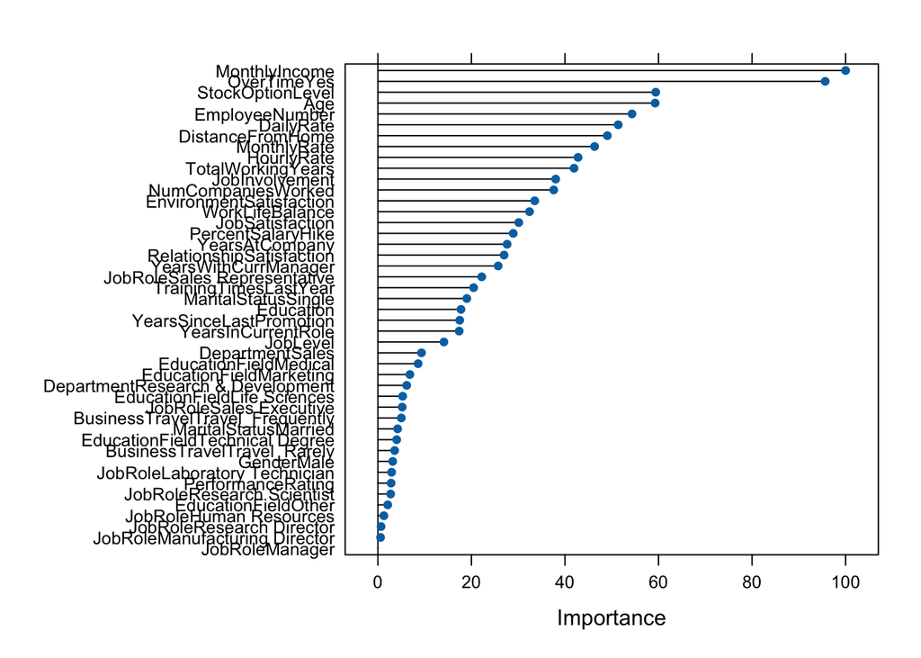

```r
X_rf <- varImp(model_rf)
plot(X_rf)
```

We can see the Importance factor range with top 3 most important variables are MonthlyIncome, OverTime and StockOptionLevel. Variable Age standing at 4th place but has very close important value to StockOptionLevel

Next reduce to the top 3: MonthlyIncome,OverTime and StockOptionLevel to train the model with NaiveBayes

```r
data3 <- data %>% select(c("Attrition","MonthlyIncome","OverTime","StockOptionLevel"))
set.seed(1234)
ind3 <- createDataPartition(data3$Attrition,p=0.7,list=FALSE)
training3 <- data3[ind,]
testing3  <- data3[-ind,]

model_nb3 <- train(Attrition~.,data=training3,method="nb")
predict3 <- predict(model_nb3,newdata=testing3)
confusionMatrix(factor(testing3$Attrition),predict3,positive="Yes")
```

```
## Confusion Matrix and Statistics
##
##           Reference
## Prediction  No Yes
##        No  213   6
##        Yes  32  10
##
##                Accuracy : 0.8544
##                  95% CI : (0.8057, 0.8949)
##     No Information Rate : 0.9387
##     P-Value [Acc > NIR] : 1
##
##                   Kappa : 0.281
##
##  Mcnemar's Test P-Value : 5.002e-05
##
##             Sensitivity : 0.62500
##             Specificity : 0.86939
##          Pos Pred Value : 0.23810
##          Neg Pred Value : 0.97260
##              Prevalence : 0.06130
##          Detection Rate : 0.03831
##    Detection Prevalence : 0.16092
##       Balanced Accuracy : 0.74719
##
##        'Positive' Class : Yes
##
```

With using only 3 variables, we have similar Accuracy and Specificity score in comparison to Random Forest, but significantly lower Sensitivity score. However, both Sensitivity and Specificity score are larger than 0.6, which satifies the requirement

Next, in order to have better explanation, we plot the Decision Tree:

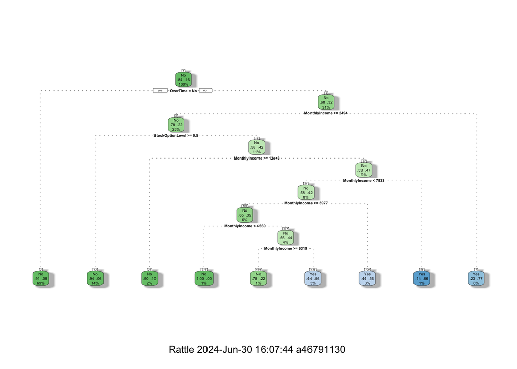

```r
model_dt <- rpart(Attrition~.,data=training3,method="class")
fancyRpartPlot(model_dt)
```

From Decision Tree plotting, we have several findings:

##### - If MonthlyIncome is more than $2494, employee now will pay attention to the StockOptionLevel, if this level is more than 0.5, they are likely stay back.

##### - Some of the subsequent splitting nodes are purely based on level of MonthlySalary.

Next in order to avoid overfitting, I will perform K-fold cross validation with NB (K=10)

```r
fitControl <- trainControl(method="cv",number=10)
model_Kfold_nb <- train(Attrition~.,data=training3,
                        trControl=fitControl,
                        preProcess=c("center","scale"),
                        method="nb")

print(model_Kfold_nb)
```

```
## Naive Bayes
##
## 609 samples
##   3 predictor
##   2 classes: 'No', 'Yes'
##
## Pre-processing: centered (3), scaled (3)
## Resampling: Cross-Validated (10 fold)
## Summary of sample sizes: 548, 549, 548, 548, 547, 548, ...
## Resampling results across tuning parameters:
##
##   usekernel  Accuracy   Kappa
##   FALSE      0.8522325  0.3162237
##    TRUE      0.8391169  0.0000000
##
## Tuning parameter 'fL' was held constant at a value of 0
## Tuning
##  parameter 'adjust' was held constant at a value of 1
## Accuracy was used to select the optimal model using the largest value.
## The final values used for the model were fL = 0, usekernel = FALSE and adjust
##  = 1.
```

```r
predict_Kfold <- predict(model_Kfold_nb,newdata=testing3)
confusionMatrix(factor(testing3$Attrition),predict_Kfold,positive="Yes")
```

```
## Confusion Matrix and Statistics
##
##           Reference
## Prediction  No Yes
##        No  213   6
##        Yes  32  10
##
##                Accuracy : 0.8544
##                  95% CI : (0.8057, 0.8949)
##     No Information Rate : 0.9387
##     P-Value [Acc > NIR] : 1
##
##                   Kappa : 0.281
##
##  Mcnemar's Test P-Value : 5.002e-05
##
##             Sensitivity : 0.62500
##             Specificity : 0.86939
##          Pos Pred Value : 0.23810
##          Neg Pred Value : 0.97260
##              Prevalence : 0.06130
##          Detection Rate : 0.03831
##    Detection Prevalence : 0.16092
##       Balanced Accuracy : 0.74719
##
##        'Positive' Class : Yes
##
```

Using K-fold cross validation, we are able to train the model to avoid the overfitting. Next we will apply the trained K-fold cross validation Naive Bayes model to predict the validation data:

First, load the validation data and select only 3 most sensitive variables, then apply the model to predict output

```r
val_data <- read.csv("CaseStudy2CompSet No Attrition.csv")
val_data3 <- val_data  %>% select(c("MonthlyIncome","OverTime","StockOptionLevel"))
predict_val3 <- as.character(predict(model_Kfold_nb,val_data3))
```

Save output to csv:

```r
outputv <- cbind(val_data$ID,predict_val3)
colnames(outputv) <- c("ID","Attrition")
write.csv(outputv,"TueVu_CaseStudy1_prediction.csv",row.names = FALSE)
```